# Data Visualization: Day 1

Erik Westlund

2025-06-10

# Welcome to Data Visualization

## Housekeeping

- Who am I?
- Contact information
- Course materials

## Who am I?

- I am a data scientist at the Johns Hopkins Bloomberg School of Public Health
- I work out of the Johns Hopkins Biostatistics Center in the Department of Biostatistics
- I was trained in the social sciences and have worked profesionally as a data scientist and software developer for over 10 years

## Contact information

- Email: ewestlund@jhu.edu

## Course materials

- [Course GitHub repository](https://github.com/erikwestlund/data-viz-summer-25):  
  https://github.com/erikwestlund/data-viz-summer-25
- [CoursePlus Website](https://courseplus.jhu.edu/core/index.cfm/go/course.home/coid/23902/):  
  https://courseplus.jhu.edu/core/index.cfm/  
  go/course.home/coid/23902/

## Course Goals

- Understanding of core data visualization concepts
- Develop strong data science & data visualization workflows
- Learn to produce high-quality data visualizations
- Learn to communicate effectively with and about data visualizations

## Course Outline

- Introduction to data visualization
- Tooling & worfklow
- Data preparation
- Grammar of graphics
- Making good, honest graphics
- Dashboards

# Introduction to Data Visualization

## Edward Tufte: Graphical Excellence is….

Edward Tufte

> “Graphical excellence is the well-designed presentation of interesting data—a matter of substance, of statistics, and of design…”

*Edward Tufte, The Visual Display of Quantitative Information, 1983*

## Dense

Edward Tufte

> “It is that which gives to the view the great number of ideas in the shortest time with the least ink in the smallest space…”

*Edward Tufte, The Visual Display of Quantitative Information, 1983*

## Multivariate

Edward Tufte

> “It is nearly always multivariate…”

*Edward Tufte, The Visual Display of Quantitative Information, 1983*

## Truthful

Edward Tufte

> “Graphical excellence requires telling the truth about the data…”

*Edward Tufte, The Visual Display of Quantitative Information, 1983*

## Exemplar: Napoleon’s March

[figure not shown]

Charles Minard’s Napoleon’s March

## Achieving Minard’s Graphical Excellence

> “[Minard’s classic image] can be described and admired, but there are no compositional principles on how to create that one wonder graphic in a million.””

*Edward Tufte, The Visual Display of Quantitative Information, 1983*

## For The Rest of Us

Instead, Tufte suggests:

- “[For] more routine, workaday designs”
- “[Have] a properly chosen format and design”
- “Use words, numbers, and drawing together”
- “[D]isplay an accessible complexity of detail”
- “Avoid content-free decoration, including chartjunk”

We will revisit more of Tufte’s principles throughout the course.

# Tooling & Workflow

- It is worth investing in learning your tools
- A good data visualization workflow requires good tooling and workflow
- Below we will discuss some of the tools we will use in this course and why we use them

## Required Software For This Course

## R

- We will rely mostly on R for this course
- R can be downloaded from [r-project.org](https://www.r-project.org/)

[figure not shown]

R Logo

## `ggplot2`

- `ggplot2` is a powerful package for creating data visualizations
- It is built on the grammar of graphics
- It is a declarative grammar for data visualization

ggplot2 Logo

## git

- `git` is a powerful tool for version control
- It allows you to
  - track changes to your code
  - revert to previous versions of your code
  - collaborate with others on your code
  - maintain multiple branches/versions of your code
  - and more

[figure not shown]

git Logo

## GitHub

- `git` is not GitHub
- GitHub is a web-based platform for hosting and collaborating on code
- It is technically a remote repository for `git`
- It gives you a place to store your code and collaborate with others
- It is free for open source projects

[figure not shown]

GitHub Logo

## Scientific Notebooks

- Notebooks are a powerful way to work with data and do data visualization
- They allow you to embed code, text, and visualizations in a single document
- They thus allow you to easily share both the process and the results of your work
- I do not require a specific notebook system for this course, but I will be using Quarto for examples

[figure not shown]

Notebook Logo

## Notebooks: Quarto

- Quarto is an open source scientific and technical publishing system
- You can create reports, websites, presentations, and books with Quarto
- This presentation is built with Quarto
- You can embed Python, R, and other code in in plaintext Quarto documents
- Quarto renders down to a document in HTML, PDF, or Word format

Quarto Logo

## RMarkdown

- RMarkdown is a way to create documents that mix R code and text
- It integrates with RStudio well and has a very similar workflow to Quarto
- RMarkdown renders down to a document in HTML, PDF, or Word format; the files them selves are plain text
- Easy to store notebooks in version control with git

RMarkdown Logo

## Jupyter

- Jupyter is a notebook system popular with Python users
- Jupyter stores code and results in the same document (Quarto/RMarkdown render into a separate document)
- Jupyter supports R and other languages
- Jupyter stores itself as JSON (javascript object notation) files and are not as easy to diff in git

[figure not shown]

Jupyter Logo

## Optional/Popular Software

## RStudio

- RStudio is a powerful IDE for R
- It is free and open source
- It helps you understand what is in your environment (e.g., variables, functions, packages, etc.)
- It also makes it easy to view your visualizations as you make them

[figure not shown]

RStudio Logo

## Python

- Python is a powerful general purpose programming language that is very popular in the data science community, especially in machine learning
- It has A-tier data management and scientific computing libraries, such as `pandas` and `numpy`
- It has a large ecosystem of packages for data visualization, including `matplotlib` and `seaborn`

[figure not shown]

Python Logo

## LLMs

- LLMs are commonly used to help with code
- Common ones used in data science are ChatGPT, Claude, Gemini, and GitHub’s Copilot
- They can help you write code, debug code, and write documentation
- They can also make mistakes, so you cannot blindly trust their work

[figure not shown]

GitHub Copilot Logo

# AI, LLMs, and Data Visualization

## AI and Data Visualization

- AI and LLMs are becoming more and more powerful
- They can help you with many data-related tasks, but require care
- They are allowed in this course, but you are responsible for checking their work

## My Philosophy

- I use LLMs in nearly all aspects of my work
- I have found that there is now less value in being able to “make computer do something” and more in high level concepts
- To that extent, in this course we will try to focus a little more on concepts and less on `ggplot2` syntax, since LLMs really can mostly solve technical visualization problems

# Prerequisites for Today

## Tools To Install

- R: Install at [r-project.org](https://www.r-project.org/)
- RStudio: Install at [rstudio.com](https://posit.co/products/open-source/rstudio/)
- Git: Install at [git-scm.com](https://git-scm.com/)

## Accounts To Create

- GitHub: Create an account at [github.com](https://github.com/)

## Setup Tasks

You may need to configure your git username and email.

```bash
git config --global user.name "Your Name"
git config --global user.email "your.email@example.com"
```

On Windows, you can run this in “Git Bash”. On Mac, you can run this in the terminal.

# Project Organization & Tooling

## Before We Do Actual Visualization

- I am spending a lot of time on tools and organization
- This may seem off-topic, but I assure you it is not
- Efficient workflows and reproducible work are key to success in data science

## Benefits Of Being Organized

- **Efficiency**: Find files quickly
- **Reproducibility**: Others can follow your work
- **Collaboration**: Team members understand your structure
- **Maintenance**: Easier to update and fix issues
- **Scalability**: Structure grows with your project

## Naming Convention Challenges

- Files need to be:
  - Easy to find
  - Easy to understand
  - Easy to sort
  - Easy to version control
- Common problems:
  - Unclear file purposes
  - Inconsistent naming
  - Missing execution order
  - Lost files in nested directories
  - Confusion about latest versions

## Course Naming Conventions

I recommend these conventions:

```
work/
├── example_*         # Learning examples
├── ps1_*             # Problem set 1
├── ps2_*             # Problem set 2
├── ps3_*             # Problem set 3
├── final_project_*   # Final project
├── shared_*          # Shared resources
└── data/             # Data directory
```

- Prefixes indicate purpose
- Numbers show execution order
- It is a best practice to document your structure in a README

## Real-World Flexibility

- These conventions are a starting point
- Real projects often need:
  - Different structures for different teams
  - Adaptation as projects grow
  - Balance between consistency and flexibility
  - Documentation of changes

## Directory Structure Options

1. Flat Structure:

   ```
   work/
   ├── data_prep.qmd
   ├── analysis.qmd
   └── data/
   ```

2. Nested Structure:

   ```
   work/
   ├── data_prep/
   │   └── data_prep.qmd
   ├── analysis/
   │   └── analysis.qmd
   └── data/
   ```

## The Challenge of Subdirectories

**Relative Paths are Tricky!**

- Files in subdirectories need to reference parent directories
- Paths like `../../data/file.csv` are:
  - Error-prone
  - Hard to maintain
  - Break when moving files
  - Confusing to read

## The `.Rproj` File

- Defines your project root
- Sets the working directory
- Stores project settings
- Makes paths relative to project root
- Essential for project portability

## The `here` Package

```r
library(here)

# Instead of "../../data/file.csv"
read_csv(here("data", "file.csv"))
```

- Builds paths from project root
- Works from any subfolder
- More readable than `../`
- More maintainable

## Benefits of Good Path Management

- Paths work from anywhere
- No more `../` counting
- More maintainable
- More portable
- Easier collaboration

### When to Change Structure?

- As project complexity grows
- When working with multiple datasets
- When collaborating with others
- When sharing code with different audiences

# Getting Started with RStudio, Projects, Quarto, and `git`

## Goals

- Learn the data science workflow: RStudio, projects, Quarto, and `git`
- Set up your course workspace
- Create your first notebook

## Fork/Open the Course Repository

1. Fork the course repo on GitHub
2. In RStudio: File -> New Project -> From Version Control
3. Paste your fork URL and create

## Exploring the Example Project

1. Open `examples/project-example/`
2. Notice the structure:
   - `_quarto.yml` for configuration
   - Numbered notebooks
   - `data/` directory
   - `.gitignore`

## Setting Up Your Work Directory

1. Create new project in `work/` using RStudio (File -> New Project -> Existing Directory)
2. Select the “work” directory in the repository we just forked

I have tested this and RStudio handles the remote repository in the directory one higher up.

## Your Work Directory

**Important!**

The `work/` directory is your personal workspace for **everything** in this course:

- All homework assignments
- Course projects
- Learning examples
- Your final project

**You are responsible for:**

- Keeping your work organized
- Following the naming conventions
- Maintaining a clean project structure
- Documenting your organization in README

This is your space - keep it clean and organized!

## Configuring Your Project (1/2)

Let’s get a file set up to work with Quarto and have data to read from.

1. Copy `_quarto.yml` from `examples` to `_quarto.yml` in your new project
2. Create `data/` directory

## Configuring Your Project (2/2)

We are now going to create a file called `.gitignore` to tell git to ignore certain files.

1. Create a file called `.gitignore` (if it doesn’t already exist)

## Understanding `.gitignore`

**Never Commit Sensitive Data!**

- `.gitignore` tells Git which files to ignore
- Critical for:
  - Protecting sensitive data
  - Preventing accidental commits
  - Keeping repositories clean

## Why `.gitignore` Matters

- **Data Privacy**:
  - Health data is sensitive
  - Patient information must be protected
  - Legal requirements (HIPAA, etc.)
  - Ethical obligations
- **Repository Health**:
  - Prevents large binary files
  - Avoids temporary files
  - Keeps repository size manageable
  - Makes collaboration easier

## Our `.gitignore` Setup

With the course-wide .gitiginore repository file, you will see these lines:

```
work/data/*


work/.Rproj.user/
work/.Rhistory
work/.RData
```

- `work/data/*`: Keeps all data files in the work directory local
- `work/.Rproj.user`: RStudio temporary files
- `work/.Rhistory`: Command history
- `work/.RData`: R workspace files

## Creating Your First Notebook (1/4)

In RStudio:

- Click File -> New File -> Quarto Document
- In the dialog:
  - Title: “Data Preparation Example”
  - Author: Your Name
  - Format: HTML
  - Template: Default
- Click “Create”
- Save as `example_cars_1_data_prep.qmd` in your `work/` directory

## Notebook Setup (2/4)

In RStudio:

- The YAML header will be automatically created at the top of your file
- It will look like this:

```yaml
---
title: "Data Preparation Example"
format: html
---
```

You can remove the `editor: visual` line – we’re going to try to work with text.

## Data Preparation (3/4)

Let’s create the data preparation setup file.

Include this as a setup block:

````r
```{r setup-prep}
#| echo: false
#| message: false
library(dplyr)
library(readr)
library(stringr)
library(ggplot2)
```
````

And then this to load and prepare the data:

````r
```{r load-data}
# Load and prepare data
mtcars_clean <- mtcars |>
  mutate(
    car_name = rownames(mtcars),
    make = word(car_name, 1),  # First word is make
    model = str_remove(car_name, paste0(make, " ")),  # Rest is model
    efficiency = mpg / wt
  )

# Save processed data
write_csv(mtcars_clean, "data/mtcars_clean.csv")
```
````

## Render the File (4/4)

- Render the file to see the results (click the “Render” button above the editor)
- We will get two outputs:
  1. A rendered HTML file
  2. A data file stored in the `data/` directory

## Create an Analysis Notebook (1/2)

In RStudio:

- Click File -> New File -> Quarto Document
- In the dialog:
  - Title: “Data Analysis Example”
  - Author: Your Name
  - Format: HTML
  - Template: Default
- Click “Create”
- Save as `example_cars_2_analysis.qmd` in your `work/` directory

## Set Up the Analysis Notebook (2/2)

````r
```{r setup-analysis}
#| echo: false
#| message: false
library(dplyr)
library(readr)
library(ggplot2)
library(forcats)
```
````

````r
```{r load-processed}
# Load processed data
df <- read_csv("data/mtcars_clean.csv")
df |> head()
```
````

## Version Control – Save our Work (1/2)

You have:

1. Forked the course repository from GitHub
2. Cloned your fork to your local machine

Now, let’s set up version control in your project.

## Option 1: Using RStudio’s Git Interface

1. In RStudio, go to Tools → Version Control → Project Setup
2. Select “Git” as the version control system
3. Click “Create Repository”
4. In the Git tab (usually in the top-right panel):
   - Click “Add” to stage all files (or select individual files)
   - Enter commit message: “Initial project setup”
   - Click “Commit”
   - Click “Push” to sync with your fork

## Option 2: Using Terminal Commands

1. In the terminal:

   ```bash
   git add .
   git commit -m "Initial project setup"
   git push
   ```

## Version Control Workflow

### Option A: Using RStudio’s Git Interface

1. Stage changes: Click “Add” in the Git tab
2. Commit: Enter message and click “Commit”
3. Push: Click “Push” to sync with your fork

### Option B: Using Terminal Commands

1. Stage changes: `git add .`
2. Commit: `git commit -m "Description of changes"`
3. Push: `git push`

Choose whichever method you’re most comfortable with as both accomplish the same thing!

## Summarize

- We are now at a point where we have a clean, reproducible workflow
- We’ve created a two-step workflow for data preparation and analysis
- We’ve committed our code to GitHub
- This workflow puts you ahead of the curve

## Homework Assignment

- Problem Set 1 is due tomorrow; see the assignment
- Your job is to create a bar chart, scatter plot, and histogram of data from any data set (you can use the mtcars data set if you want)
- You should comment on what the purpose of the plot is and what it communicates (a few sentences each is fine)
- You should follow the workflow you learned today
- Give the files sensible names, commit them to GitHub, and email me the link to your repository
- Problems with GitHub? Email me your answers.

## Visualization Workflow Preview

- Let’s create a few very, very simple plots
- We’re not going to get into the details of the code until tomorrow
- For now, let’s just put a couple points on the scoreboard

## Code Blocks

From here on out, it’s up to you to create the code blocks, such as below:

````r
```{r}

# Code goes here

```
````

## Histogram (Base R)

- Histograms are easy to plot using base R or `ggplot2`
- Base R:

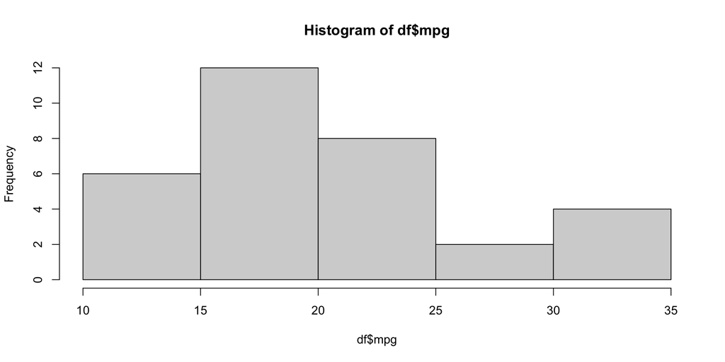

```r
hist(df$mpg)
```

## Histogram (ggplot2)

- In our course, we will focus on `ggplot2`
- Tomorrow we will explicate the logic behind the `gg` or grammar of graphics

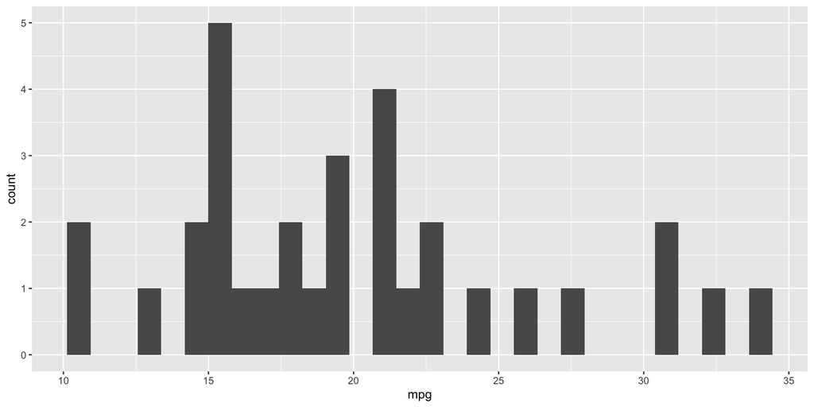

```r
ggplot(df, aes(x = mpg)) +
  geom_histogram()
```

## Histogram (ggplot2) notes

- Note how the Base R and ggplot2 versions differ: what do you notice?
- What might we do to improve the ggplot2 version?
- A histogram is a workhourse “utility” plot. When is it worth “polishing” it?

## Histogram polishing (but only a little bit)

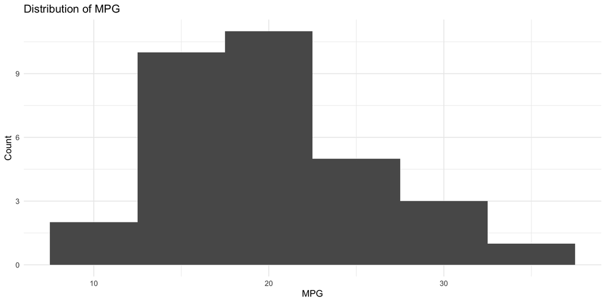

```r
ggplot(df, aes(x = mpg)) +
  geom_histogram(binwidth = 5) +
  theme_minimal() +
  labs(
    title = "Distribution of MPG",
    x = "MPG",
    y = "Count"
  )
```

## Bar Chart v1

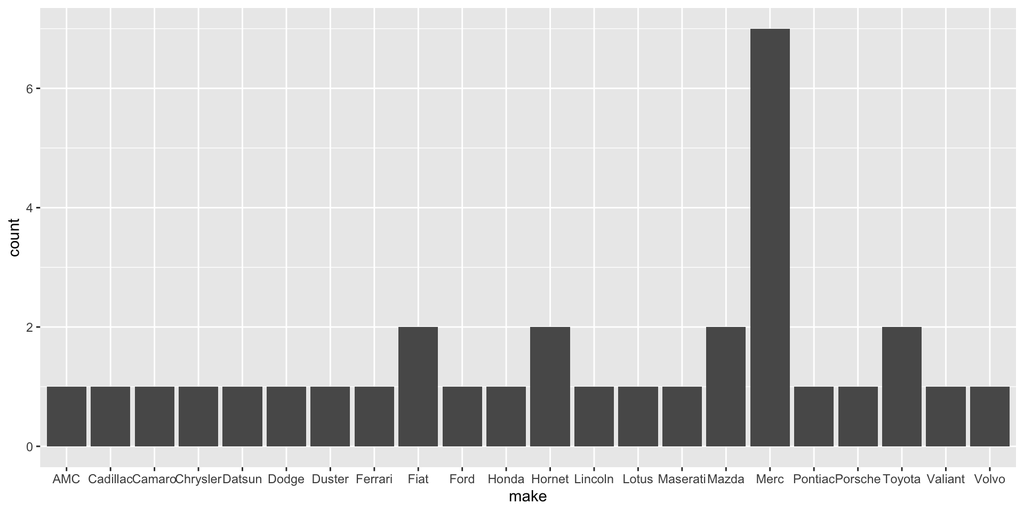

```r
# Count cars by make
bar_plot_v1 <- df |>
  ggplot(aes(x = make)) +
  geom_bar()

bar_plot_v1
```

What’s wrong with this?

## Possible Bar Chart Improvements

- coord_flip(): Flip the x and y axes
- theme_minimal(): Use a minimal theme
- labs(): Add labels to the plot

```r
bar_plot_v2 <- df |>
  ggplot(aes(x = make)) +
  geom_bar() +
  coord_flip() +
  theme_minimal() +
  labs(
    title = "Number of Cars by Make",
    x = "Make",
    y = "Count"
  )
```

## Bar Chart v2

```r
bar_plot_v2
```

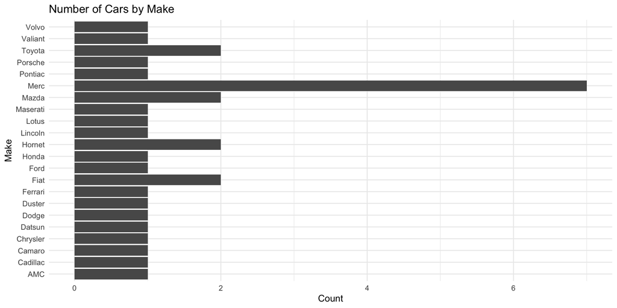

## Possible Bar Chart v2 Improvements

- Sort by count

```r
bar_plot_v3 <- df |>
  count(make) |>
  mutate(make = fct_reorder(make, n)) |>
  ggplot(aes(x = make, y = n)) +
  geom_bar(stat = "identity") +
  coord_flip() +
  theme_minimal() +
  labs(
    title = "Number of Cars by Make",
    x = "Make",
    y = "Count"
  )
```

## Bar Chart v3

```r
bar_plot_v3
```

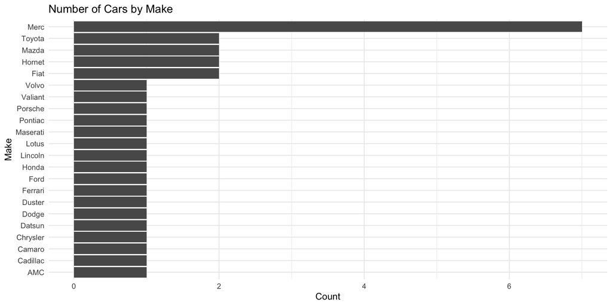

## Bar Chart v3 Improvements

```r
bar_plot_v4 <- bar_plot_v3 +
  labs(
    title = "Distribution of Car Makes in the mtcars Dataset",
    x = NULL, # Note that because of coord_flip(), x is now the y axis
    y = "Number of Cars in Fleet"
  ) +
  theme(panel.grid.major.x = element_blank())
```

## Bar Chart v4

```r
bar_plot_v4
```

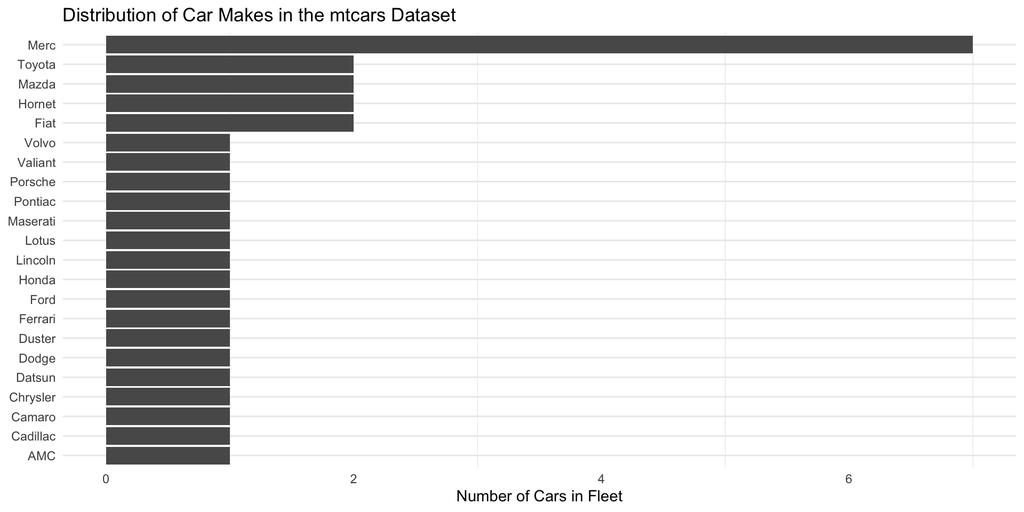

## Bar Chart Thoughts

- We see the workflow of building good visualizations with ggplot2
- We also see that this figure is still not perfect. We could consider:
  - Making it colorful
  - Making the title **bold**
  - Adding a subtitle
  - Using text annotations

## Scatterplot v1

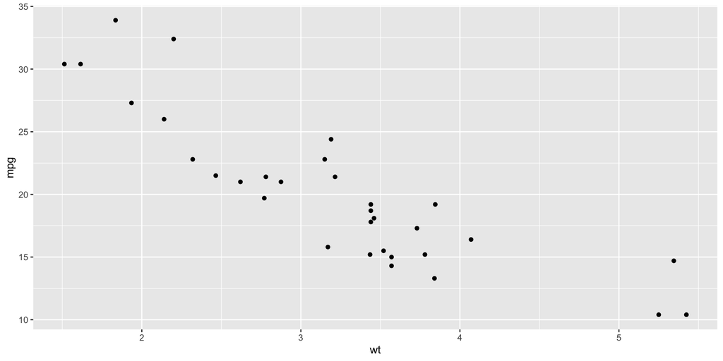

```r
scatter_plot <- df |>
  ggplot(aes(x = wt, y = mpg)) +
  geom_point()

scatter_plot
```

## Scatterplot Improvements

- We can add a trend line
- We could soften up the gray background
- We could add a title and labels

## Scatterplot v2

```r
scatter_plot_v2 <- scatter_plot +
  geom_smooth(method = "lm") +
  theme_minimal() +
  labs(
    title = "Relationship between Weight and MPG",
    x = "Weight (1000 lbs)",
    y = "MPG"
  )
```

## Scatterplot v2

```r
scatter_plot_v2
```

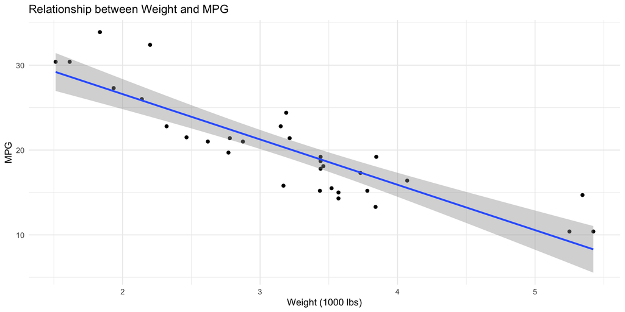

## Scatterplot thoughts

- This is looking better
- In a real analysis, we may want to annotate certain points or facet by some other variable

## Fancier Plotting

- If you look at our code set up, we created an `efficiency` variable
- What if we tried to compare efficiency across makes? How might we proceed?

```r
efficiency_by_make <- df |>
  group_by(make) |>
  summarise(avg_efficiency = mean(efficiency)) |>
  mutate(make = fct_reorder(make, avg_efficiency)) |>
  ggplot(aes(x = make, y = avg_efficiency)) +
  geom_bar(stat = "identity") +
  coord_flip() +
  theme_minimal() +
  theme(panel.grid.major.y = element_blank()) +
  labs(
    title = "Average Fuel Efficiency by Make",
    x = NULL,
    y = "Average Efficiency (MPG/1000 lbs)"
  )
```

## Efficiency By Make Plot

```r
efficiency_by_make
```

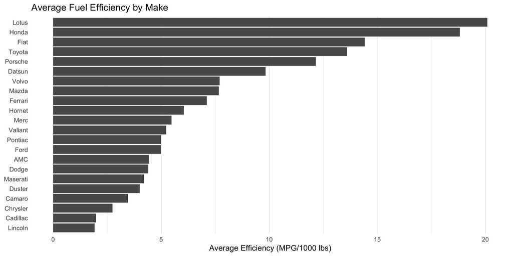